# Predicting Grades

## Analysis

### Summary

The results of our logistical regression model and Hosmer and Lemeshow goodness of fit test determined two things:

1. A logistical model is a valid option to use as the $p$-value equaled `0.7098`.
2. Our logistical model found the variables `AnalysisTotal`, `SkillsQuizzesTotal`, `FinalExam`, and `Math325NotebookOrganization` to hold significant value in predicting whether you will receive an *A* or not. Additionally, the lower the AIC value the better.

| Predictor Variable | AIC | Null Deviance | Residual Deviance | 1st $p$-val | 2nd $p$-val | 3rd $p$-val | 4th $p$-val |
| --- | --- | --- | --- | --- | --- | --- | --- |
| AnalysisTotal + SkillsQuizzesTotal + FinalExam + Math325NotebookOrganization | 30.552 | 166.055 | 20.552 | 0.00587 | 0.00414 | 0.00231 | 0.01911 |

#### Analysis Graph

```r
summary(Grades$AnalysisTotal)
summary(Grades$SkillsQuizzesTotal)
summary(Grades$FinalExam)
summary(Grades$Math325NotebookOrganization)
```

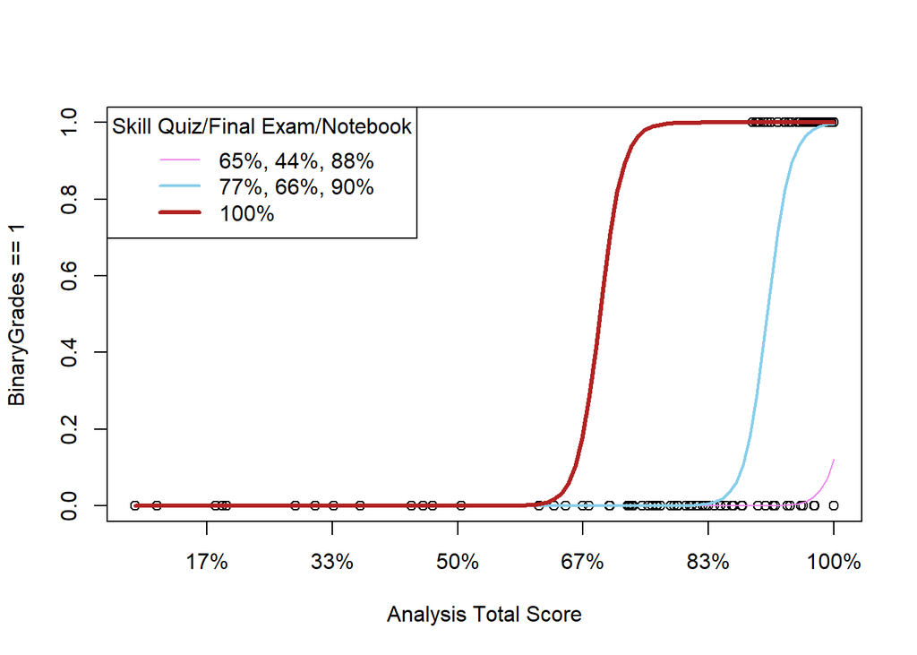

```r
WithFinal.glm <- glm(BinaryGrades == 1 ~ AnalysisTotal + SkillsQuizzesTotal + FinalExam + Math325NotebookOrganization, data = Grades, family = binomial)

bf <- WithFinal.glm$coefficients

plot(BinaryGrades == 1 ~ AnalysisTotal, data=Grades, xaxt='n', xlab="Analysis Total Score") #xaxt are turned off because the numbers given don't mean anything. Instead we
axis(1, at=seq(5,30,5), labels=c("17%","33%","50%","67%","83%","100%"))

SQ = 9.843; FE = 8.70; NB = 4.394;
curve(exp(bf[1] + bf[2]*AT + bf[3]*SQ + bf[4]*FE + bf[5]*NB)/(1+ exp(bf[1] + bf[2]*AT + bf[3]*SQ + bf[4]*FE + bf[5]*NB)), xname="AT", add=TRUE, lwd=1, col = "violet")
SQ = 11.492; FE = 13.28; NB = 4.500;
curve(exp(bf[1] + bf[2]*AT + bf[3]*SQ + bf[4]*FE + bf[5]*NB)/(1+ exp(bf[1] + bf[2]*AT + bf[3]*SQ + bf[4]*FE + bf[5]*NB)), xname="AT", add=TRUE, lwd=2, col = "skyblue")
SQ = 15.000; FE = 20; NB = 5.000;
curve(exp(bf[1] + bf[2]*AT + bf[3]*SQ + bf[4]*FE + bf[5]*NB)/(1+ exp(bf[1] + bf[2]*AT + bf[3]*SQ + bf[4]*FE + bf[5]*NB)), xname="AT", add=TRUE, lwd=3, col = "firebrick")
legend("topleft", legend=c("65%, 44%, 88%", "77%, 66%, 90%", "100%"), title="Skill Quiz/Final Exam/Notebook", lwd=c(1,2,3), col=c("violet", "skyblue", "firebrick"))
```

#### Skills Quiz Graph

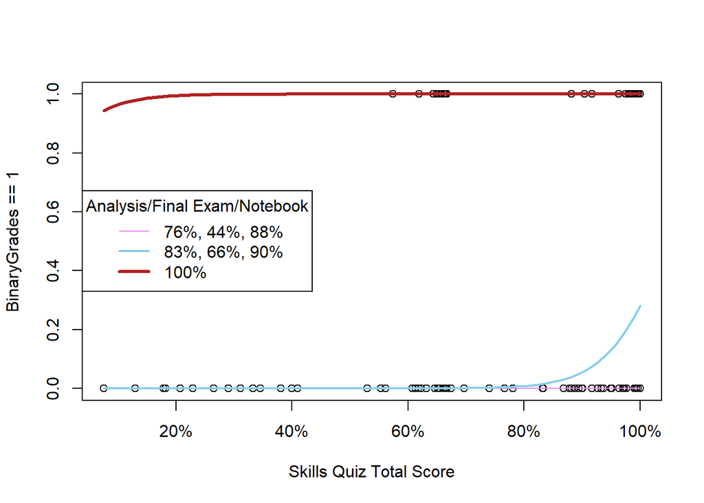

```r
plot(BinaryGrades == 1 ~ SkillsQuizzesTotal, data=Grades, xaxt='n', xlab="Skills Quiz Total Score") #xaxt are turned off because the numbers given don't mean anything. Instead we
axis(1, at=seq(3, 15, 3), labels=c("20%","40%","60%","80%", "100%"))

AT = 22.948; FE = 8.70; NB = 4.394;
curve(exp(bf[1] + bf[2]*AT + bf[3]*SQ + bf[4]*FE + bf[5]*NB)/(1+ exp(bf[1] + bf[2]*AT + bf[3]*SQ + bf[4]*FE + bf[5]*NB)), xname="SQ", add=TRUE, lwd=1, col = "violet")
AT = 24.884; FE = 13.28; NB = 4.500;
curve(exp(bf[1] + bf[2]*AT + bf[3]*SQ + bf[4]*FE + bf[5]*NB)/(1+ exp(bf[1] + bf[2]*AT + bf[3]*SQ + bf[4]*FE + bf[5]*NB)), xname="SQ", add=TRUE, lwd=2, col = "skyblue")
AT = 30.000; FE = 20; NB = 5.000;
curve(exp(bf[1] + bf[2]*AT + bf[3]*SQ + bf[4]*FE + bf[5]*NB)/(1+ exp(bf[1] + bf[2]*AT + bf[3]*SQ + bf[4]*FE + bf[5]*NB)), xname="SQ", add=TRUE, lwd=3, col = "firebrick")
legend("left", legend=c("76%, 44%, 88%", "83%, 66%, 90%", "100%"), title="Analysis/Final Exam/Notebook", lwd=c(1,2,3), col=c("violet", "skyblue", "firebrick"))
```

#### Final Exam Graph

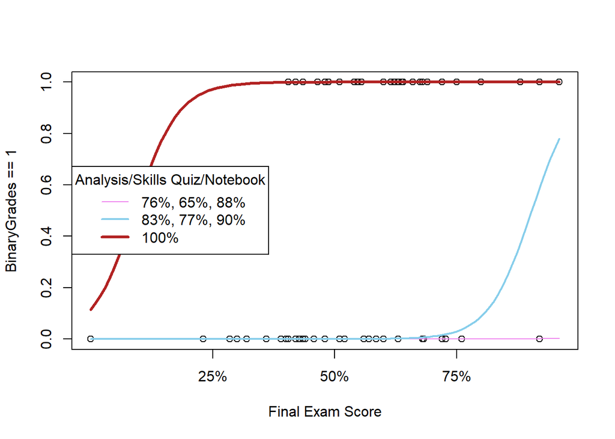

```r
plot(BinaryGrades == 1 ~ FinalExam, data=Grades, xaxt='n', xlab="Final Exam Score") #xaxt are turned off because the numbers given don't mean anything. Instead we
axis(1, at=seq(5, 20, 5), labels=c("25%","50%","75%", "100%"))

AT = 22.948; SQ = 9.843; NB = 4.394;
curve(exp(bf[1] + bf[2]*AT + bf[3]*SQ + bf[4]*FE + bf[5]*NB)/(1+ exp(bf[1] + bf[2]*AT + bf[3]*SQ + bf[4]*FE + bf[5]*NB)), xname="FE", add=TRUE, lwd=1, col = "violet")
AT = 24.884; SQ = 11.492; NB = 4.500;
curve(exp(bf[1] + bf[2]*AT + bf[3]*SQ + bf[4]*FE + bf[5]*NB)/(1+ exp(bf[1] + bf[2]*AT + bf[3]*SQ + bf[4]*FE + bf[5]*NB)), xname="FE", add=TRUE, lwd=2, col = "skyblue")
AT = 30.000; SQ = 15.000; NB = 5.000;
curve(exp(bf[1] + bf[2]*AT + bf[3]*SQ + bf[4]*FE + bf[5]*NB)/(1+ exp(bf[1] + bf[2]*AT + bf[3]*SQ + bf[4]*FE + bf[5]*NB)), xname="FE", add=TRUE, lwd=3, col = "firebrick")
legend("left", legend=c("76%, 65%, 88%", "83%, 77%, 90%", "100%"), title="Analysis/Skills Quiz/Notebook", lwd=c(1,2,3), col=c("violet", "skyblue", "firebrick"))
```

#### Notebook Graph

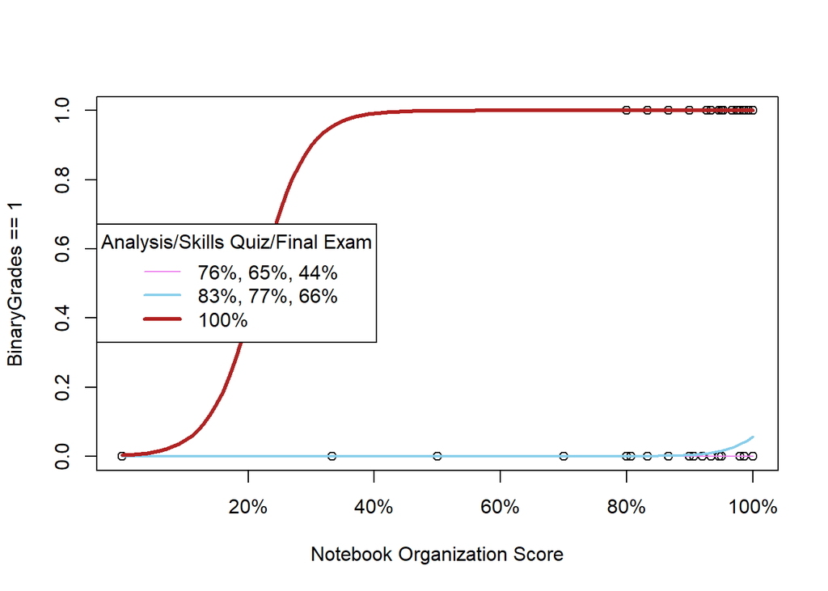

```r
plot(BinaryGrades == 1 ~ Math325NotebookOrganization, xaxt='n', data=Grades, xlab="Notebook Organization Score") #xaxt are turned off because the numbers given don't mean anything. Instead we
axis(1, at=seq(1, 5, 1), labels=c("20%","40%","60%","80%", "100%"))

AT = 22.948; SQ = 9.843; FE = 8.70;
curve(exp(bf[1] + bf[2]*AT + bf[3]*SQ + bf[4]*FE + bf[5]*NB)/(1+ exp(bf[1] + bf[2]*AT + bf[3]*SQ + bf[4]*FE + bf[5]*NB)), xname="NB", add=TRUE, lwd=1, col = "violet")
AT = 24.884; SQ = 11.492; FE = 13.28;
curve(exp(bf[1] + bf[2]*AT + bf[3]*SQ + bf[4]*FE + bf[5]*NB)/(1+ exp(bf[1] + bf[2]*AT + bf[3]*SQ + bf[4]*FE + bf[5]*NB)), xname="NB", add=TRUE, lwd=2, col = "skyblue")
AT = 30.000; SQ = 15.000; FE = 20;
curve(exp(bf[1] + bf[2]*AT + bf[3]*SQ + bf[4]*FE + bf[5]*NB)/(1+ exp(bf[1] + bf[2]*AT + bf[3]*SQ + bf[4]*FE + bf[5]*NB)), xname="NB", add=TRUE, lwd=3, col = "firebrick")
legend("left", legend=c("76%, 65%, 44%", "83%, 77%, 66%", "100%"), title="Analysis/Skills Quiz/Final Exam", lwd=c(1,2,3), col=c("violet", "skyblue", "firebrick"))
```

### Interpretation

#### Don’t Show

In order to determine and predict how a student can best obtain an **A** in Math 325, we need to understand how I am building the logistical regression model. While it is easy enough to graph the results of the logistical model, it’s harder to interpret the graph because it is plotted using probability. So to interpret the results, we look to the log of the odds.

$$\underbrace{log(\frac{\pi_i}{1 - \pi_i})}_\text{Odds for Y_i = 1} = \underbrace{\beta_0 + \beta_1 x_i \ + \ ... \ + \beta_p x_{ip}}_\text{linear regression}$$

Or in other words by exponentiating the log of the odds we get:

$$\underbrace{\frac{\pi_i}{1 - \pi_i}}_\text{Odds for Y_i = 1} = e^{\overbrace{\beta_0 + \beta_1 x_i \ + \ ... \ + \beta_p x_{ip}}^\text{linear regression}} = e^{\beta_0} e^{\beta_1 x_{i1}}...e^{\beta_p x_{ip}}$$

By so doing, we are now able to see that as $X_i$ equals 1 or anything greater than 0, then we are able determine the change in our baseline, $e^{\beta_0}$, because we are left with the coefficient. Here is the mathmatical formula that I will be using to determine the results:

$$P(Y_i = 1 | x_{i1}, x_{i12}, x_{i3}, x_{i4}) = \frac{e^{\beta_0 + \beta_1 x_{i1} + \beta_2 x_{i2} + \beta_3 x_{i3} + \beta_4 x_{i4}}}{1 + e^{\beta_0 + \beta_1 x_{i1} + \beta_2 x_{i2} + \beta_3 x_{i3} + \beta_4 x_{i4}}} = \pi_i$$

where you see an observation $i$, it will mean:

```r
summary(Grades$AnalysisTotal)
summary(Grades$SkillsQuizzesTotal)
summary(Grades$FinalExam)
summary(Grades$Math325NotebookOrganization)
```

| Variable | Value | Explanation |
| --- | --- | --- |
| $Y_{i}$ | `1 == A` | A number 1 equals a successful obtainment of the grade letter *A* |
| $Y_{i}$ | `0 == Other` | A number 0 equals any grade letter other than an *A* |
| $x_{i1}$ | 2.136 to 30 points | Students range of points within the variable `AnalysisTotal` |
| $x_{i2}$ | 1.136 to 15 points | Students range of points within the variable `SkillsQuizzesTotal` |
| $x_{i3}$ | 0 to 19.20 points | Students range of points within the variable `FinalExam` |
| $x_{i4}$ | 0 to 5 points | Students range of points within the variable `Math325NotebookOrganization` |

Note that if all $\beta's$ besides $\beta_0$ in the above mathmatical model equaled zero, then my $x$ variables provide no insight whether a student will be able to obtain an *A*. Thus we can say our hypotheses for this analysis is:

$$H_0: \beta_0 = 0 \\
H_a: \beta_0 \neq 0$$
$$H_0: \beta_1 = 0 \\
H_a: \beta_1 \neq 0$$
$$H_0: \beta_2 = 0 \\
H_a: \beta_2 \neq 0$$
$$H_0: \beta_3 = 0 \\
H_a: \beta_3 \neq 0$$
$$H_0: \beta_4 = 0 \\
H_a: \beta_4 \neq 0$$

##### Is this test worth pursuing?

```r
NoFinal.glm <- glm(BinaryGrades == 1 ~ AnalysisTotal + Math325NotebookOrganization + SkillsQuizzesTotal, data = Grades, family = binomial)
#summary(NoFinal.glm)

WithFinal.glm <- glm(BinaryGrades == 1 ~ AnalysisTotal + SkillsQuizzesTotal + FinalExam + Math325NotebookOrganization, data = Grades, family = binomial)
#summary(WithFinal.glm)

pander(hoslem.test(NoFinal.glm$y, NoFinal.glm$fitted))
```

Hosmer and Lemeshow goodness of fit (GOF) test: `NoFinal.glm$y, NoFinal.glm$fitted`

| Test statistic | df | P value |
| --- | --- | --- |
| 3.212 | 8 | 0.9203 |

```r
pander(hoslem.test(WithFinal.glm$y, WithFinal.glm$fitted))
```

Hosmer and Lemeshow goodness of fit (GOF) test: `WithFinal.glm$y, WithFinal.glm$fitted`

| Test statistic | df | P value |
| --- | --- | --- |
| 5.439 | 8 | 0.7098 |

Usually a Hosmer-Lemeshow Goodness of Fit Test is ran after conducting a logistical regression test first because the required numbers needed to complete the formula for a Goodness of Fit test come from the logistical test. We will analyze that logistical test later, yet I would like to first answer the first hypothesis that running a logistical regression test on the obtainment of an *A* is a good fit and to thus continue forward. The Goodness of Fit’s p-values are `0.9203` and `0.7098` meaning that we fail to reject the null hypothesis because our $\sigma$ = .05.

##### General Information

Two tests were run for a particular reason. If you as a student would like to see how your work throughout the semester can determine your grade then you will use this information:

```r
summary(NoFinal.glm)
```

```
##
## Call:
## glm(formula = BinaryGrades == 1 ~ AnalysisTotal + Math325NotebookOrganization +
##     SkillsQuizzesTotal, family = binomial, data = Grades)
##
## Deviance Residuals:
##    Min      1Q  Median      3Q     Max
## -2.716  -0.110   0.000   0.304   2.008
##
## Coefficients:
##                             Estimate Std. Error z value Pr(>|z|)
## (Intercept)                 -54.4995    11.4772  -4.748 2.05e-06 ***
## AnalysisTotal                 1.2033     0.2749   4.377 1.20e-05 ***
## Math325NotebookOrganization   3.7763     1.3001   2.905  0.00368 **
## SkillsQuizzesTotal            0.3181     0.1416   2.247  0.02466 *
## ---
## Signif. codes:  0 '***' 0.001 '**' 0.01 '*' 0.05 '.' 0.1 ' ' 1
##
## (Dispersion parameter for binomial family taken to be 1)
##
##     Null deviance: 166.055  on 119  degrees of freedom
## Residual deviance:  49.404  on 116  degrees of freedom
## AIC: 57.404
##
## Number of Fisher Scoring iterations: 8
```

But if you would like to see how your work throughout the semester along with your Final Exam score impacts your grade letter then you would use this:

```r
summary(WithFinal.glm)
```

```
##
## Call:
## glm(formula = BinaryGrades == 1 ~ AnalysisTotal + SkillsQuizzesTotal +
##     FinalExam + Math325NotebookOrganization, family = binomial,
##     data = Grades)
##
## Deviance Residuals:
##      Min        1Q    Median        3Q       Max
## -2.57917  -0.00840   0.00000   0.03499   1.49938
##
## Coefficients:
##                              Estimate Std. Error z value Pr(>|z|)
## (Intercept)                 -112.9468    36.9899  -3.053  0.00226 **
## AnalysisTotal                  2.1920     0.7957   2.755  0.00587 **
## SkillsQuizzesTotal             1.2711     0.4433   2.867  0.00414 **
## FinalExam                      1.1243     0.3690   3.047  0.00231 **
## Math325NotebookOrganization    5.2156     2.2257   2.343  0.01911 *
## ---
## Signif. codes:  0 '***' 0.001 '**' 0.01 '*' 0.05 '.' 0.1 ' ' 1
##
## (Dispersion parameter for binomial family taken to be 1)
##
##     Null deviance: 166.055  on 119  degrees of freedom
## Residual deviance:  20.552  on 115  degrees of freedom
## AIC: 30.552
##
## Number of Fisher Scoring iterations: 11
```

For my purposes, I will stick with the second model, but with this word of advice. Your work throughout the semester will most definitely impact your performance on your Final Exam grade. If you do not perform well on the work through the semester, then you can bet your Final Exam score will not be a great. Thus impacting your likelihood of obtaining an *A*.

Here we see that the estimate of probability or $\pi_i$ is

$$P(Y_i = 1 | x_{i1}, x_{i12}, x_{i3}, x_{i4}) = \frac{e^{-112.9468 + 2.1920 x_{i1} + 1.2711 x_{i2} + 1.1243 x_{i3} + 5.2156 x_{i4}}}{1 + e^{-112.9468 + 2.1920 x_{i1} + 1.2711 x_{i2} + 1.1243 x_{i3} + 5.2156 x_{i4}}} = \pi_i$$

What this shows are our estimates of our $\beta's$ and how we will calculate this equation. All $p$-values in this regression model are below our level level of signifiance 0.05; meaning that there is significant evidence to determine that each $\beta \neq 0$. This states that each variable significantly contributes in the ability to predict whether a student will obtain an *A* or not.

##### Checking Assumptions

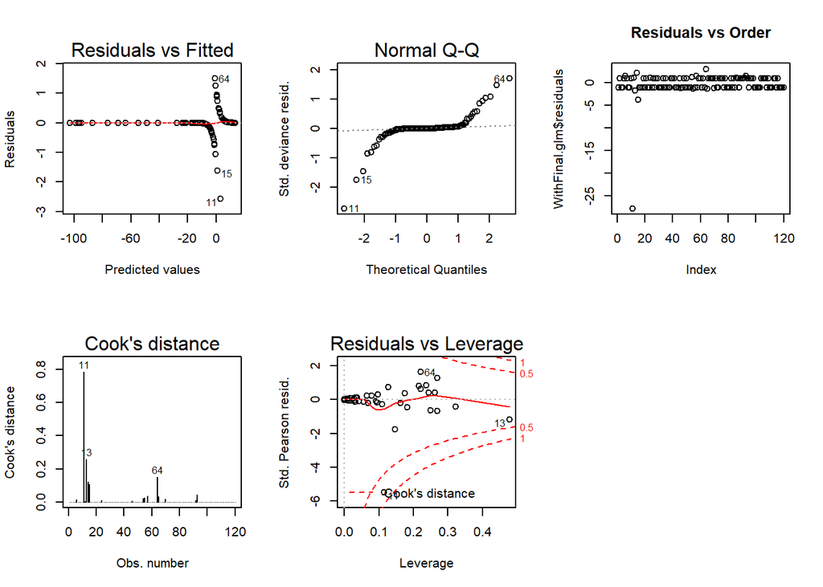

```r
# Check Assumptions
par(mfrow=c(2,3))
plot(WithFinal.glm, which=1:2)
plot(WithFinal.glm$residuals, main = "Residuals vs Order")
plot(WithFinal.glm, which=c(4,5))
#plot(mylm, which = 1)
# qqPlot(mylm$residuals, main = "Q-Q Plot of Residuals", id = FALSE)
```

I don’t not believe these are needed, but it good to review these assumptions since I have been doing this throughout the semester.

#### Show Dirty Work

##### Starting Off

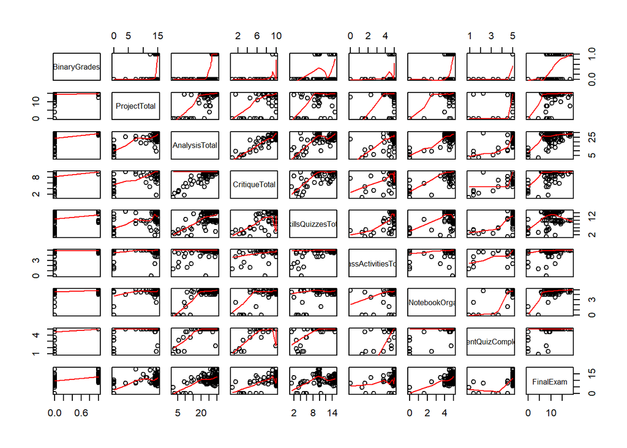

```r
Grades <- grade325 %>%
  mutate(BinaryGrades = ifelse(FinalGrade == "A", 1, 0))

pairs(Grades[,c("BinaryGrades", "ProjectTotal", "AnalysisTotal", "CritiqueTotal", "SkillsQuizzesTotal", "ClassActivitiesTotal", "Math325NotebookOrganization", "AssessmentQuizCompletionTotal", "FinalExam")], panel = panel.smooth)
```

What’s the best column to start with? It looks like `ProjectTotal`, `AnalysisTotal`, `Math325NotebookOrganization`, and `FinalExam`. Let’s start with `ProjectTotal` and work our way through each individual column.

##### Two Dimensional

```r
Grades.glm1 <- glm(BinaryGrades == 1 ~ ProjectTotal, data = Grades, family = binomial)
summary(Grades.glm1)
```

```
##
## Call:
## glm(formula = BinaryGrades == 1 ~ ProjectTotal, family = binomial,
##     data = Grades)
##
## Deviance Residuals:
##      Min        1Q    Median        3Q       Max
## -1.51916  -1.04919  -0.00004   0.87054   2.40675
##
## Coefficients:
##              Estimate Std. Error z value Pr(>|z|)
## (Intercept)  -20.9114     6.7526  -3.097  0.00196 **
## ProjectTotal   1.4458     0.4591   3.149  0.00164 **
## ---
## Signif. codes:  0 '***' 0.001 '**' 0.01 '*' 0.05 '.' 0.1 ' ' 1
##
## (Dispersion parameter for binomial family taken to be 1)
##
##     Null deviance: 166.06  on 119  degrees of freedom
## Residual deviance: 123.87  on 118  degrees of freedom
## AIC: 127.87
##
## Number of Fisher Scoring iterations: 8
```

```r
Grades.glm2 <- glm(BinaryGrades == 1 ~ AnalysisTotal, data = Grades, family = binomial)
summary(Grades.glm2)
```

```
##
## Call:
## glm(formula = BinaryGrades == 1 ~ AnalysisTotal, family = binomial,
##     data = Grades)
##
## Deviance Residuals:
##      Min        1Q    Median        3Q       Max
## -2.50649  -0.16491  -0.00001   0.41607   1.43710
##
## Coefficients:
##               Estimate Std. Error z value Pr(>|z|)
## (Intercept)   -31.1710     6.2806  -4.963 6.94e-07 ***
## AnalysisTotal   1.1423     0.2252   5.071 3.95e-07 ***
## ---
## Signif. codes:  0 '***' 0.001 '**' 0.01 '*' 0.05 '.' 0.1 ' ' 1
##
## (Dispersion parameter for binomial family taken to be 1)
##
##     Null deviance: 166.055  on 119  degrees of freedom
## Residual deviance:  62.879  on 118  degrees of freedom
## AIC: 66.879
##
## Number of Fisher Scoring iterations: 8
```

```r
Grades.glm3 <- glm(BinaryGrades == 1 ~ CritiqueTotal, data = Grades, family = binomial)
summary(Grades.glm3)
```

```
##
## Call:
## glm(formula = BinaryGrades == 1 ~ CritiqueTotal, family = binomial,
##     data = Grades)
##
## Deviance Residuals:
##      Min        1Q    Median        3Q       Max
## -1.50043  -0.58853  -0.00004   0.88568   1.83626
##
## Coefficients:
##               Estimate Std. Error z value Pr(>|z|)
## (Intercept)   -28.0546     9.0797   -3.09  0.00200 **
## CritiqueTotal   2.8788     0.9138    3.15  0.00163 **
## ---
## Signif. codes:  0 '***' 0.001 '**' 0.01 '*' 0.05 '.' 0.1 ' ' 1
##
## (Dispersion parameter for binomial family taken to be 1)
##
##     Null deviance: 166.06  on 119  degrees of freedom
## Residual deviance: 113.16  on 118  degrees of freedom
## AIC: 117.16
##
## Number of Fisher Scoring iterations: 8
```

```r
Grades.glm4 <- glm(BinaryGrades == 1 ~ SkillsQuizzesTotal, data = Grades, family = binomial)
summary(Grades.glm4)
```

```
##
## Call:
## glm(formula = BinaryGrades == 1 ~ SkillsQuizzesTotal, family = binomial,
##     data = Grades)
##
## Deviance Residuals:
##     Min       1Q   Median       3Q      Max
## -1.4966  -0.9802  -0.4229   0.9083   1.5674
##
## Coefficients:
##                    Estimate Std. Error z value Pr(>|z|)
## (Intercept)        -3.05145    0.81974  -3.722 0.000197 ***
## SkillsQuizzesTotal  0.25176    0.06623   3.802 0.000144 ***
## ---
## Signif. codes:  0 '***' 0.001 '**' 0.01 '*' 0.05 '.' 0.1 ' ' 1
##
## (Dispersion parameter for binomial family taken to be 1)
##
##     Null deviance: 166.06  on 119  degrees of freedom
## Residual deviance: 147.74  on 118  degrees of freedom
## AIC: 151.74
##
## Number of Fisher Scoring iterations: 3
```

```r
Grades.glm5 <- glm(BinaryGrades == 1 ~ ClassActivitiesTotal, data = Grades, family = binomial)
summary(Grades.glm5)
```

```
##
## Call:
## glm(formula = BinaryGrades == 1 ~ ClassActivitiesTotal, family = binomial,
##     data = Grades)
##
## Deviance Residuals:
##      Min        1Q    Median        3Q       Max
## -1.30919  -1.30919  -0.00437   1.05110   2.03836
##
## Coefficients:
##                      Estimate Std. Error z value Pr(>|z|)
## (Intercept)           -17.681      6.923  -2.554   0.0107 *
## ClassActivitiesTotal    3.597      1.400   2.569   0.0102 *
## ---
## Signif. codes:  0 '***' 0.001 '**' 0.01 '*' 0.05 '.' 0.1 ' ' 1
##
## (Dispersion parameter for binomial family taken to be 1)
##
##     Null deviance: 166.06  on 119  degrees of freedom
## Residual deviance: 146.40  on 118  degrees of freedom
## AIC: 150.4
##
## Number of Fisher Scoring iterations: 7
```

```r
Grades.glm6 <- glm(BinaryGrades == 1 ~ Math325NotebookOrganization, data = Grades, family = binomial)
summary(Grades.glm6)
```

```
##
## Call:
## glm(formula = BinaryGrades == 1 ~ Math325NotebookOrganization,
##     family = binomial, data = Grades)
##
## Deviance Residuals:
##      Min        1Q    Median        3Q       Max
## -1.60325  -0.95504  -0.00052   0.84382   2.22864
##
## Coefficients:
##                             Estimate Std. Error z value Pr(>|z|)
## (Intercept)                 -15.8271     4.0560  -3.902 9.53e-05 ***
## Math325NotebookOrganization   3.3577     0.8522   3.940 8.14e-05 ***
## ---
## Signif. codes:  0 '***' 0.001 '**' 0.01 '*' 0.05 '.' 0.1 ' ' 1
##
## (Dispersion parameter for binomial family taken to be 1)
##
##     Null deviance: 166.06  on 119  degrees of freedom
## Residual deviance: 132.80  on 118  degrees of freedom
## AIC: 136.8
##
## Number of Fisher Scoring iterations: 6
```

```r
Grades.glm7 <- glm(BinaryGrades == 1 ~ AssessmentQuizCompletionTotal, data = Grades, family = binomial)
summary(Grades.glm7)
```

```
##
## Call:
## glm(formula = BinaryGrades == 1 ~ AssessmentQuizCompletionTotal,
##     family = binomial, data = Grades)
##
## Deviance Residuals:
##    Min      1Q  Median      3Q     Max
## -1.242  -1.242   0.000   1.114   1.114
##
## Coefficients:
##                               Estimate Std. Error z value Pr(>|z|)
## (Intercept)                    -186.91   15245.33  -0.012     0.99
## AssessmentQuizCompletionTotal    37.41    3049.07   0.012     0.99
##
## (Dispersion parameter for binomial family taken to be 1)
##
##     Null deviance: 164.76  on 118  degrees of freedom
## Residual deviance: 146.34  on 117  degrees of freedom
##   (1 observation deleted due to missingness)
## AIC: 150.34
##
## Number of Fisher Scoring iterations: 19
```

```r
Grades.glm8 <- glm(BinaryGrades == 1 ~ FinalExam, data = Grades, family = binomial)
summary(Grades.glm8)
```

```
##
## Call:
## glm(formula = BinaryGrades == 1 ~ FinalExam, family = binomial,
##     data = Grades)
##
## Deviance Residuals:
##     Min       1Q   Median       3Q      Max
## -2.4307  -0.8308  -0.1328   0.8814   1.7865
##
## Coefficients:
##             Estimate Std. Error z value Pr(>|z|)
## (Intercept) -4.72692    1.00877  -4.686 2.79e-06 ***
## FinalExam    0.41454    0.08749   4.738 2.16e-06 ***
## ---
## Signif. codes:  0 '***' 0.001 '**' 0.01 '*' 0.05 '.' 0.1 ' ' 1
##
## (Dispersion parameter for binomial family taken to be 1)
##
##     Null deviance: 166.06  on 119  degrees of freedom
## Residual deviance: 126.02  on 118  degrees of freedom
## AIC: 130.02
##
## Number of Fisher Scoring iterations: 5
```

```r
# b.grades1 <- coef(Grades.glm1)
# plot(BinaryGrades == 1 ~ Analysis5, data = Grades)
# curve(exp(b.grades1[1] + b.grades1[2]*x)/( 1 + exp(b.grades1[1] + b.grades1[2]*x) ), add = TRUE)
# lines(lowess(Grades$Analysis5, Grades$FinalGrade == "A"), col = "red")
```

| Predictor Variable | AIC | Null Deviance | Residual Deviance | $p$-value |
| --- | --- | --- | --- | --- |
| ProjectTotal | 127.87 | 166.06 | 123.87 | 0.00164 |
| AnalysisTotal | 66.879 | 166.055 | 62.879 | 3.95e-07 |
| CritiqueTotal | 117.16 | 166.06 | 113.16 | 0.00163 |
| SkillsQuizzesTotal | 151.74 | 166.06 | 147.74 | 0.000144 |
| ClassActivitiesTotal | 150.4 | 166.06 | 146.40 | 0.0102 |
| Math325NotebookOrganization | 136.8 | 166.06 | 132.80 | 8.14e-05 |
| AssessmentQuizCompletionTotal | 150.34 | 164.76 | 146.34 | 0.99 |
| FinalExam | 130.02 | 166.06 | 126.02 | 2.16e-06 |

In ranking order it goes `AnalysisTotal`, `CritiqueTotal`, `ProjectTotal`, `FinalExam`, `Math325NotebookOrganization`, `AssessmentQuizCompletionTotal`, `ClassActivitiesTotal`, and `SkillsQuizzesTotal`. Since I do not know what `ProjectTotal` is, I will not continue using it. Additionally, since `FinalExam` comes towards the very end of the semester and is not a factor you can really control throughout the semester, I will forgo using it.

##### Three Dimensional

```r
Grades.glm9 <- glm(BinaryGrades == 1 ~ AnalysisTotal + CritiqueTotal, data = Grades, family = binomial)
summary(Grades.glm9)
```

```
##
## Call:
## glm(formula = BinaryGrades == 1 ~ AnalysisTotal + CritiqueTotal,
##     family = binomial, data = Grades)
##
## Deviance Residuals:
##      Min        1Q    Median        3Q       Max
## -2.51630  -0.09288   0.00000   0.41838   1.73414
##
## Coefficients:
##               Estimate Std. Error z value Pr(>|z|)
## (Intercept)    -44.108     12.868  -3.428 0.000609 ***
## AnalysisTotal    1.071      0.227   4.720 2.35e-06 ***
## CritiqueTotal    1.508      1.164   1.296 0.194869
## ---
## Signif. codes:  0 '***' 0.001 '**' 0.01 '*' 0.05 '.' 0.1 ' ' 1
##
## (Dispersion parameter for binomial family taken to be 1)
##
##     Null deviance: 166.055  on 119  degrees of freedom
## Residual deviance:  60.473  on 117  degrees of freedom
## AIC: 66.473
##
## Number of Fisher Scoring iterations: 9
```

```r
Grades.glm10 <- glm(BinaryGrades == 1 ~ AnalysisTotal + Math325NotebookOrganization, data = Grades, family = binomial)
summary(Grades.glm10)
```

```
##
## Call:
## glm(formula = BinaryGrades == 1 ~ AnalysisTotal + Math325NotebookOrganization,
##     family = binomial, data = Grades)
##
## Deviance Residuals:
##     Min       1Q   Median       3Q      Max
## -2.8724  -0.1447   0.0000   0.3173   1.5903
##
## Coefficients:
##                             Estimate Std. Error z value Pr(>|z|)
## (Intercept)                 -46.3091     9.7621  -4.744 2.10e-06 ***
## AnalysisTotal                 1.1804     0.2551   4.627 3.72e-06 ***
## Math325NotebookOrganization   3.0013     1.1338   2.647  0.00812 **
## ---
## Signif. codes:  0 '***' 0.001 '**' 0.01 '*' 0.05 '.' 0.1 ' ' 1
##
## (Dispersion parameter for binomial family taken to be 1)
##
##     Null deviance: 166.055  on 119  degrees of freedom
## Residual deviance:  54.867  on 117  degrees of freedom
## AIC: 60.867
##
## Number of Fisher Scoring iterations: 8
```

```r
Grades.glm11 <- glm(BinaryGrades == 1 ~ AnalysisTotal + AssessmentQuizCompletionTotal, data = Grades, family = binomial)
summary(Grades.glm11)
```

```
##
## Call:
## glm(formula = BinaryGrades == 1 ~ AnalysisTotal + AssessmentQuizCompletionTotal,
##     family = binomial, data = Grades)
##
## Deviance Residuals:
##     Min       1Q   Median       3Q      Max
## -2.6128  -0.1158   0.0000   0.3745   1.3916
##
## Coefficients:
##                                 Estimate Std. Error z value Pr(>|z|)
## (Intercept)                    -207.1178 17510.6115  -0.012    0.991
## AnalysisTotal                     1.1983     0.2402   4.989 6.08e-07 ***
## AssessmentQuizCompletionTotal    34.9097  3502.1222   0.010    0.992
## ---
## Signif. codes:  0 '***' 0.001 '**' 0.01 '*' 0.05 '.' 0.1 ' ' 1
##
## (Dispersion parameter for binomial family taken to be 1)
##
##     Null deviance: 164.759  on 118  degrees of freedom
## Residual deviance:  56.528  on 116  degrees of freedom
##   (1 observation deleted due to missingness)
## AIC: 62.528
##
## Number of Fisher Scoring iterations: 15
```

```r
Grades.glm12 <- glm(BinaryGrades == 1 ~ AnalysisTotal + ClassActivitiesTotal, data = Grades, family = binomial)
summary(Grades.glm12)
```

```
##
## Call:
## glm(formula = BinaryGrades == 1 ~ AnalysisTotal + ClassActivitiesTotal,
##     family = binomial, data = Grades)
##
## Deviance Residuals:
##     Min       1Q   Median       3Q      Max
## -2.7643  -0.1043   0.0000   0.3258   1.3040
##
## Coefficients:
##                      Estimate Std. Error z value Pr(>|z|)
## (Intercept)          -57.7301    14.1879  -4.069 4.72e-05 ***
## AnalysisTotal          1.2667     0.2672   4.741 2.13e-06 ***
## ClassActivitiesTotal   4.7057     2.0443   2.302   0.0213 *
## ---
## Signif. codes:  0 '***' 0.001 '**' 0.01 '*' 0.05 '.' 0.1 ' ' 1
##
## (Dispersion parameter for binomial family taken to be 1)
##
##     Null deviance: 166.055  on 119  degrees of freedom
## Residual deviance:  54.845  on 117  degrees of freedom
## AIC: 60.845
##
## Number of Fisher Scoring iterations: 8
```

```r
Grades.glm13 <- glm(BinaryGrades == 1 ~ AnalysisTotal + SkillsQuizzesTotal, data = Grades, family = binomial)
summary(Grades.glm13)
```

```
##
## Call:
## glm(formula = BinaryGrades == 1 ~ AnalysisTotal + SkillsQuizzesTotal,
##     family = binomial, data = Grades)
##
## Deviance Residuals:
##     Min       1Q   Median       3Q      Max
## -2.3530  -0.1452   0.0000   0.4074   1.6151
##
## Coefficients:
##                    Estimate Std. Error z value Pr(>|z|)
## (Intercept)        -34.7598     7.2067  -4.823 1.41e-06 ***
## AnalysisTotal        1.1798     0.2404   4.909 9.17e-07 ***
## SkillsQuizzesTotal   0.2069     0.1251   1.654   0.0982 .
## ---
## Signif. codes:  0 '***' 0.001 '**' 0.01 '*' 0.05 '.' 0.1 ' ' 1
##
## (Dispersion parameter for binomial family taken to be 1)
##
##     Null deviance: 166.055  on 119  degrees of freedom
## Residual deviance:  60.106  on 117  degrees of freedom
## AIC: 66.106
##
## Number of Fisher Scoring iterations: 8
```

| Predictor Variable | AIC | Null Deviance | Residual Deviance | First $p$-value | 2nd variable’s $p$-value |
| --- | --- | --- | --- | --- | --- |
| AnalysisTotal | 66.879 | 166.055 | 62.879 | 3.95e-07 | N/A |
| AnalysisTotal + CritiqueTotal | 66.473 | 166.055 | 60.473 | 2.35e-06 | 0.194869 |
| AnalysisTotal + Math325NotebookOrganization | 60.867 | 166.055 | 54.867 | 3.72e-06 | 0.00812 |
| AnalysisTotal + AssessmentQuizCompletionTotal | 62.528 | 164.759 | 56.528 | 6.08e-07 | 0.992 |
| AnalysisTotal + ClassActivitiesTotal | 60.845 | 166.055 | 54.845 | 2.13e-06 | 0.0213 |
| AnalysisTotal + SkillsQuizzesTotal | 66.106 | 166.055 | 60.106 | 9.17e-07 | 0.0982 |

```r
Grades.glm14 <- glm(BinaryGrades == 1 ~ AnalysisTotal + Math325NotebookOrganization + ClassActivitiesTotal, data = Grades, family = binomial)
summary(Grades.glm14)
```

```
##
## Call:
## glm(formula = BinaryGrades == 1 ~ AnalysisTotal + Math325NotebookOrganization +
##     ClassActivitiesTotal, family = binomial, data = Grades)
##
## Deviance Residuals:
##      Min        1Q    Median        3Q       Max
## -2.95926  -0.09719   0.00000   0.28867   1.71685
##
## Coefficients:
##                             Estimate Std. Error z value Pr(>|z|)
## (Intercept)                 -65.5252    16.9691  -3.861 0.000113 ***
## AnalysisTotal                 1.2403     0.2799   4.431 9.38e-06 ***
## Math325NotebookOrganization   2.3419     1.2091   1.937 0.052770 .
## ClassActivitiesTotal          4.1944     2.3838   1.760 0.078479 .
## ---
## Signif. codes:  0 '***' 0.001 '**' 0.01 '*' 0.05 '.' 0.1 ' ' 1
##
## (Dispersion parameter for binomial family taken to be 1)
##
##     Null deviance: 166.055  on 119  degrees of freedom
## Residual deviance:  50.848  on 116  degrees of freedom
## AIC: 58.848
##
## Number of Fisher Scoring iterations: 9
```

Surprisingly, a combination of Analysis, Math Notebook, and Class Activites does not determine the grade better due to higher p-values. I also did a quick look into how an interaction of Analysis with Notebook and Analysis with Class Activities would fair and all variables became insignificant. Let’s try something else then. Let’s go back to the original good variables and plug them in.

##### Four Dimensional

```r
Grades.glm15 <- glm(BinaryGrades == 1 ~ AnalysisTotal + Math325NotebookOrganization + CritiqueTotal, data = Grades, family = binomial)
summary(Grades.glm15)
```

```
##
## Call:
## glm(formula = BinaryGrades == 1 ~ AnalysisTotal + Math325NotebookOrganization +
##     CritiqueTotal, family = binomial, data = Grades)
##
## Deviance Residuals:
##      Min        1Q    Median        3Q       Max
## -2.84261  -0.08458   0.00000   0.32576   1.82882
##
## Coefficients:
##                             Estimate Std. Error z value Pr(>|z|)
## (Intercept)                 -52.9758    13.8005  -3.839 0.000124 ***
## AnalysisTotal                 1.1294     0.2578   4.382 1.18e-05 ***
## Math325NotebookOrganization   2.7760     1.1518   2.410 0.015949 *
## CritiqueTotal                 0.9235     1.1680   0.791 0.429137
## ---
## Signif. codes:  0 '***' 0.001 '**' 0.01 '*' 0.05 '.' 0.1 ' ' 1
##
## (Dispersion parameter for binomial family taken to be 1)
##
##     Null deviance: 166.055  on 119  degrees of freedom
## Residual deviance:  54.073  on 116  degrees of freedom
## AIC: 62.073
##
## Number of Fisher Scoring iterations: 9
```

```r
Grades.glm16 <- glm(BinaryGrades == 1 ~ AnalysisTotal + Math325NotebookOrganization + AssessmentQuizCompletionTotal, data = Grades, family = binomial)
summary(Grades.glm16)
```

```
##
## Call:
## glm(formula = BinaryGrades == 1 ~ AnalysisTotal + Math325NotebookOrganization +
##     AssessmentQuizCompletionTotal, family = binomial, data = Grades)
##
## Deviance Residuals:
##      Min        1Q    Median        3Q       Max
## -3.02627  -0.09655   0.00000   0.26432   1.55170
##
## Coefficients:
##                                 Estimate Std. Error z value Pr(>|z|)
## (Intercept)                    -233.4780 27846.1783  -0.008  0.99331
## AnalysisTotal                     1.2731     0.2856   4.458 8.27e-06 ***
## Math325NotebookOrganization       3.1933     1.1815   2.703  0.00687 **
## AssessmentQuizCompletionTotal    36.7773  5569.2353   0.007  0.99473
## ---
## Signif. codes:  0 '***' 0.001 '**' 0.01 '*' 0.05 '.' 0.1 ' ' 1
##
## (Dispersion parameter for binomial family taken to be 1)
##
##     Null deviance: 164.759  on 118  degrees of freedom
## Residual deviance:  48.079  on 115  degrees of freedom
##   (1 observation deleted due to missingness)
## AIC: 56.079
##
## Number of Fisher Scoring iterations: 18
```

```r
Grades.glm17 <- glm(BinaryGrades == 1 ~ AnalysisTotal + Math325NotebookOrganization + SkillsQuizzesTotal, data = Grades, family = binomial)
summary(Grades.glm17)
```

```
##
## Call:
## glm(formula = BinaryGrades == 1 ~ AnalysisTotal + Math325NotebookOrganization +
##     SkillsQuizzesTotal, family = binomial, data = Grades)
##
## Deviance Residuals:
##    Min      1Q  Median      3Q     Max
## -2.716  -0.110   0.000   0.304   2.008
##
## Coefficients:
##                             Estimate Std. Error z value Pr(>|z|)
## (Intercept)                 -54.4995    11.4772  -4.748 2.05e-06 ***
## AnalysisTotal                 1.2033     0.2749   4.377 1.20e-05 ***
## Math325NotebookOrganization   3.7763     1.3001   2.905  0.00368 **
## SkillsQuizzesTotal            0.3181     0.1416   2.247  0.02466 *
## ---
## Signif. codes:  0 '***' 0.001 '**' 0.01 '*' 0.05 '.' 0.1 ' ' 1
##
## (Dispersion parameter for binomial family taken to be 1)
##
##     Null deviance: 166.055  on 119  degrees of freedom
## Residual deviance:  49.404  on 116  degrees of freedom
## AIC: 57.404
##
## Number of Fisher Scoring iterations: 8
```

```r
Grades.glm18 <- glm(BinaryGrades == 1 ~ AnalysisTotal + ClassActivitiesTotal + CritiqueTotal, data = Grades, family = binomial)
summary(Grades.glm18)
```

```
##
## Call:
## glm(formula = BinaryGrades == 1 ~ AnalysisTotal + ClassActivitiesTotal +
##     CritiqueTotal, family = binomial, data = Grades)
##
## Deviance Residuals:
##      Min        1Q    Median        3Q       Max
## -2.73702  -0.06885   0.00000   0.33245   1.35156
##
## Coefficients:
##                      Estimate Std. Error z value Pr(>|z|)
## (Intercept)          -59.4296    14.5514  -4.084 4.42e-05 ***
## AnalysisTotal          1.2161     0.2740   4.439 9.05e-06 ***
## ClassActivitiesTotal   4.1013     2.1511   1.907   0.0566 .
## CritiqueTotal          0.6162     1.1062   0.557   0.5775
## ---
## Signif. codes:  0 '***' 0.001 '**' 0.01 '*' 0.05 '.' 0.1 ' ' 1
##
## (Dispersion parameter for binomial family taken to be 1)
##
##     Null deviance: 166.055  on 119  degrees of freedom
## Residual deviance:  54.494  on 116  degrees of freedom
## AIC: 62.494
##
## Number of Fisher Scoring iterations: 9
```

```r
Grades.glm19 <- glm(BinaryGrades == 1 ~ AnalysisTotal + ClassActivitiesTotal + AssessmentQuizCompletionTotal, data = Grades, family = binomial)
summary(Grades.glm19)
```

```
##
## Call:
## glm(formula = BinaryGrades == 1 ~ AnalysisTotal + ClassActivitiesTotal +
##     AssessmentQuizCompletionTotal, family = binomial, data = Grades)
##
## Deviance Residuals:
##      Min        1Q    Median        3Q       Max
## -2.81762  -0.09145   0.00000   0.30708   1.29313
##
## Coefficients:
##                                 Estimate Std. Error z value Pr(>|z|)
## (Intercept)                    -229.0300 26902.6227  -0.009   0.9932
## AnalysisTotal                     1.3060     0.2788   4.685  2.8e-06 ***
## ClassActivitiesTotal              3.8246     1.9193   1.993   0.0463 *
## AssessmentQuizCompletionTotal    34.9354  5380.5243   0.006   0.9948
## ---
## Signif. codes:  0 '***' 0.001 '**' 0.01 '*' 0.05 '.' 0.1 ' ' 1
##
## (Dispersion parameter for binomial family taken to be 1)
##
##     Null deviance: 164.759  on 118  degrees of freedom
## Residual deviance:  50.784  on 115  degrees of freedom
##   (1 observation deleted due to missingness)
## AIC: 58.784
##
## Number of Fisher Scoring iterations: 16
```

```r
Grades.glm20 <- glm(BinaryGrades == 1 ~ AnalysisTotal + ClassActivitiesTotal + SkillsQuizzesTotal, data = Grades, family = binomial)
summary(Grades.glm20)
```

```
##
## Call:
## glm(formula = BinaryGrades == 1 ~ AnalysisTotal + ClassActivitiesTotal +
##     SkillsQuizzesTotal, family = binomial, data = Grades)
##
## Deviance Residuals:
##     Min       1Q   Median       3Q      Max
## -2.6503  -0.1009   0.0000   0.3112   1.4314
##
## Coefficients:
##                      Estimate Std. Error z value Pr(>|z|)
## (Intercept)          -60.5271    14.9434  -4.050 5.11e-05 ***
## AnalysisTotal          1.3027     0.2827   4.608 4.07e-06 ***
## ClassActivitiesTotal   4.6378     2.0994   2.209   0.0272 *
## SkillsQuizzesTotal     0.1739     0.1286   1.352   0.1762
## ---
## Signif. codes:  0 '***' 0.001 '**' 0.01 '*' 0.05 '.' 0.1 ' ' 1
##
## (Dispersion parameter for binomial family taken to be 1)
##
##     Null deviance: 166.06  on 119  degrees of freedom
## Residual deviance:  52.97  on 116  degrees of freedom
## AIC: 60.97
##
## Number of Fisher Scoring iterations: 8
```

| Predictor Variable | AIC | Null Deviance | Residual Deviance | 1st $p$-val | 2nd $p$-val | 3rd $p$-val |
| --- | --- | --- | --- | --- | --- | --- |
| AnalysisTotal | 66.879 | 166.055 | 62.879 | 3.95e-07 | N/A | N/A |
| AnalysisTotal + Math325NotebookOrganization | 60.867 | 166.055 | 54.867 | 3.72e-06 | 0.00812 | N/A |
| AnalysisTotal + Math325NotebookOrganization + SkillsQuizzesTotal | 57.404 | 166.055 | 49.404 | 1.20e-05 | 0.00368 | 0.02466 |

There was only one combination that was useful as all other combinations had insignificant p-values. I am going to try and add FinalExam and see what happens.

##### Five Dimensional with Final Exam

```r
Grades.glm21 <- glm(BinaryGrades == 1 ~ AnalysisTotal + ClassActivitiesTotal + SkillsQuizzesTotal + FinalExam, data = Grades, family = binomial)
summary(Grades.glm21)
```

```
##
## Call:
## glm(formula = BinaryGrades == 1 ~ AnalysisTotal + ClassActivitiesTotal +
##     SkillsQuizzesTotal + FinalExam, family = binomial, data = Grades)
##
## Deviance Residuals:
##      Min        1Q    Median        3Q       Max
## -2.46858  -0.00860   0.00000   0.02918   1.44074
##
## Coefficients:
##                       Estimate Std. Error z value Pr(>|z|)
## (Intercept)          -116.9614    43.1209  -2.712  0.00668 **
## AnalysisTotal           2.2794     0.8401   2.713  0.00666 **
## ClassActivitiesTotal    5.8512     3.2512   1.800  0.07191 .
## SkillsQuizzesTotal      1.0898     0.4713   2.312  0.02076 *
## FinalExam               1.1271     0.3991   2.824  0.00474 **
## ---
## Signif. codes:  0 '***' 0.001 '**' 0.01 '*' 0.05 '.' 0.1 ' ' 1
##
## (Dispersion parameter for binomial family taken to be 1)
##
##     Null deviance: 166.055  on 119  degrees of freedom
## Residual deviance:  22.473  on 115  degrees of freedom
## AIC: 32.473
##
## Number of Fisher Scoring iterations: 11
```

```r
Grades.glm22 <- glm(BinaryGrades == 1 ~ AnalysisTotal + CritiqueTotal + SkillsQuizzesTotal + FinalExam, data = Grades, family = binomial)
summary(Grades.glm22)
```

```
##
## Call:
## glm(formula = BinaryGrades == 1 ~ AnalysisTotal + CritiqueTotal +
##     SkillsQuizzesTotal + FinalExam, family = binomial, data = Grades)
##
## Deviance Residuals:
##     Min       1Q   Median       3Q      Max
## -2.4705  -0.0060   0.0000   0.0452   1.5089
##
## Coefficients:
##                     Estimate Std. Error z value Pr(>|z|)
## (Intercept)        -110.2853    36.3164  -3.037  0.00239 **
## AnalysisTotal         1.8628     0.6055   3.076  0.00210 **
## CritiqueTotal         3.2125     1.7914   1.793  0.07292 .
## SkillsQuizzesTotal    1.2376     0.4933   2.509  0.01211 *
## FinalExam             1.1186     0.3712   3.014  0.00258 **
## ---
## Signif. codes:  0 '***' 0.001 '**' 0.01 '*' 0.05 '.' 0.1 ' ' 1
##
## (Dispersion parameter for binomial family taken to be 1)
##
##     Null deviance: 166.055  on 119  degrees of freedom
## Residual deviance:  23.645  on 115  degrees of freedom
## AIC: 33.645
##
## Number of Fisher Scoring iterations: 10
```

```r
Grades.glm23 <- glm(BinaryGrades == 1 ~ AnalysisTotal + AssessmentQuizCompletionTotal + SkillsQuizzesTotal + FinalExam, data = Grades, family = binomial)
summary(Grades.glm23)
```

```
##
## Call:
## glm(formula = BinaryGrades == 1 ~ AnalysisTotal + AssessmentQuizCompletionTotal +
##     SkillsQuizzesTotal + FinalExam, family = binomial, data = Grades)
##
## Deviance Residuals:
##      Min        1Q    Median        3Q       Max
## -2.02714  -0.02719   0.00000   0.09294   1.61867
##
## Coefficients:
##                                 Estimate Std. Error z value Pr(>|z|)
## (Intercept)                    -261.9261 26358.0013  -0.010 0.992071
## AnalysisTotal                     1.7029     0.4799   3.549 0.000387 ***
## AssessmentQuizCompletionTotal    38.6385  5271.5983   0.007 0.994152
## SkillsQuizzesTotal                0.9683     0.3650   2.653 0.007970 **
## FinalExam                         0.9168     0.2772   3.307 0.000944 ***
## ---
## Signif. codes:  0 '***' 0.001 '**' 0.01 '*' 0.05 '.' 0.1 ' ' 1
##
## (Dispersion parameter for binomial family taken to be 1)
##
##     Null deviance: 164.759  on 118  degrees of freedom
## Residual deviance:  27.128  on 114  degrees of freedom
##   (1 observation deleted due to missingness)
## AIC: 37.128
##
## Number of Fisher Scoring iterations: 20
```

```r
Grades.glm24 <- glm(BinaryGrades == 1 ~ AnalysisTotal + SkillsQuizzesTotal + FinalExam, data = Grades, family = binomial)
summary(Grades.glm24)
```

```
##
## Call:
## glm(formula = BinaryGrades == 1 ~ AnalysisTotal + SkillsQuizzesTotal +
##     FinalExam, family = binomial, data = Grades)
##
## Deviance Residuals:
##      Min        1Q    Median        3Q       Max
## -1.96501  -0.03436   0.00000   0.11015   1.59311
##
## Coefficients:
##                    Estimate Std. Error z value Pr(>|z|)
## (Intercept)        -65.4135    17.3110  -3.779 0.000158 ***
## AnalysisTotal        1.6504     0.4569   3.612 0.000304 ***
## SkillsQuizzesTotal   0.8482     0.3177   2.670 0.007591 **
## FinalExam            0.8669     0.2512   3.451 0.000559 ***
## ---
## Signif. codes:  0 '***' 0.001 '**' 0.01 '*' 0.05 '.' 0.1 ' ' 1
##
## (Dispersion parameter for binomial family taken to be 1)
##
##     Null deviance: 166.055  on 119  degrees of freedom
## Residual deviance:  29.465  on 116  degrees of freedom
## AIC: 37.465
##
## Number of Fisher Scoring iterations: 9
```

Only one model has significance: `AnalysisTotal + SkillsQuizzesTotal + FinalExam` and AIC: 37.465. Just for kicks, can we make this model any better?

```r
Grades.glm25 <- glm(BinaryGrades == 1 ~ AnalysisTotal + SkillsQuizzesTotal + FinalExam + CritiqueTotal, data = Grades, family = binomial)
summary(Grades.glm25)
```

```
##
## Call:
## glm(formula = BinaryGrades == 1 ~ AnalysisTotal + SkillsQuizzesTotal +
##     FinalExam + CritiqueTotal, family = binomial, data = Grades)
##
## Deviance Residuals:
##     Min       1Q   Median       3Q      Max
## -2.4705  -0.0060   0.0000   0.0452   1.5089
##
## Coefficients:
##                     Estimate Std. Error z value Pr(>|z|)
## (Intercept)        -110.2853    36.3164  -3.037  0.00239 **
## AnalysisTotal         1.8628     0.6055   3.076  0.00210 **
## SkillsQuizzesTotal    1.2376     0.4933   2.509  0.01211 *
## FinalExam             1.1186     0.3712   3.014  0.00258 **
## CritiqueTotal         3.2125     1.7914   1.793  0.07292 .
## ---
## Signif. codes:  0 '***' 0.001 '**' 0.01 '*' 0.05 '.' 0.1 ' ' 1
##
## (Dispersion parameter for binomial family taken to be 1)
##
##     Null deviance: 166.055  on 119  degrees of freedom
## Residual deviance:  23.645  on 115  degrees of freedom
## AIC: 33.645
##
## Number of Fisher Scoring iterations: 10
```

```r
Grades.glm26 <- glm(BinaryGrades == 1 ~ AnalysisTotal + SkillsQuizzesTotal + FinalExam + Math325NotebookOrganization, data = Grades, family = binomial)
summary(Grades.glm26)
```

```
##
## Call:
## glm(formula = BinaryGrades == 1 ~ AnalysisTotal + SkillsQuizzesTotal +
##     FinalExam + Math325NotebookOrganization, family = binomial,
##     data = Grades)
##
## Deviance Residuals:
##      Min        1Q    Median        3Q       Max
## -2.57917  -0.00840   0.00000   0.03499   1.49938
##
## Coefficients:
##                              Estimate Std. Error z value Pr(>|z|)
## (Intercept)                 -112.9468    36.9899  -3.053  0.00226 **
## AnalysisTotal                  2.1920     0.7957   2.755  0.00587 **
## SkillsQuizzesTotal             1.2711     0.4433   2.867  0.00414 **
## FinalExam                      1.1243     0.3690   3.047  0.00231 **
## Math325NotebookOrganization    5.2156     2.2257   2.343  0.01911 *
## ---
## Signif. codes:  0 '***' 0.001 '**' 0.01 '*' 0.05 '.' 0.1 ' ' 1
##
## (Dispersion parameter for binomial family taken to be 1)
##
##     Null deviance: 166.055  on 119  degrees of freedom
## Residual deviance:  20.552  on 115  degrees of freedom
## AIC: 30.552
##
## Number of Fisher Scoring iterations: 11
```

```r
Grades.glm27 <- glm(BinaryGrades == 1 ~ AnalysisTotal + SkillsQuizzesTotal + FinalExam + AssessmentQuizCompletionTotal, data = Grades, family = binomial)
summary(Grades.glm27)
```

```
##
## Call:
## glm(formula = BinaryGrades == 1 ~ AnalysisTotal + SkillsQuizzesTotal +
##     FinalExam + AssessmentQuizCompletionTotal, family = binomial,
##     data = Grades)
##
## Deviance Residuals:
##      Min        1Q    Median        3Q       Max
## -2.02714  -0.02719   0.00000   0.09294   1.61867
##
## Coefficients:
##                                 Estimate Std. Error z value Pr(>|z|)
## (Intercept)                    -261.9261 26358.0012  -0.010 0.992071
## AnalysisTotal                     1.7029     0.4799   3.549 0.000387 ***
## SkillsQuizzesTotal                0.9683     0.3650   2.653 0.007970 **
## FinalExam                         0.9168     0.2772   3.307 0.000944 ***
## AssessmentQuizCompletionTotal    38.6385  5271.5983   0.007 0.994152
## ---
## Signif. codes:  0 '***' 0.001 '**' 0.01 '*' 0.05 '.' 0.1 ' ' 1
##
## (Dispersion parameter for binomial family taken to be 1)
##
##     Null deviance: 164.759  on 118  degrees of freedom
## Residual deviance:  27.128  on 114  degrees of freedom
##   (1 observation deleted due to missingness)
## AIC: 37.128
##
## Number of Fisher Scoring iterations: 20
```

```r
Grades.glm28 <- glm(BinaryGrades == 1 ~ AnalysisTotal + SkillsQuizzesTotal + FinalExam + ClassActivitiesTotal, data = Grades, family = binomial)
summary(Grades.glm28)
```

```
##
## Call:
## glm(formula = BinaryGrades == 1 ~ AnalysisTotal + SkillsQuizzesTotal +
##     FinalExam + ClassActivitiesTotal, family = binomial, data = Grades)
##
## Deviance Residuals:
##      Min        1Q    Median        3Q       Max
## -2.46858  -0.00860   0.00000   0.02918   1.44074
##
## Coefficients:
##                       Estimate Std. Error z value Pr(>|z|)
## (Intercept)          -116.9614    43.1209  -2.712  0.00668 **
## AnalysisTotal           2.2794     0.8401   2.713  0.00666 **
## SkillsQuizzesTotal      1.0898     0.4713   2.312  0.02076 *
## FinalExam               1.1271     0.3991   2.824  0.00474 **
## ClassActivitiesTotal    5.8512     3.2512   1.800  0.07191 .
## ---
## Signif. codes:  0 '***' 0.001 '**' 0.01 '*' 0.05 '.' 0.1 ' ' 1
##
## (Dispersion parameter for binomial family taken to be 1)
##
##     Null deviance: 166.055  on 119  degrees of freedom
## Residual deviance:  22.473  on 115  degrees of freedom
## AIC: 32.473
##
## Number of Fisher Scoring iterations: 11
```

### Data

This data was provided by Brother Saunders and by downloading the data I have agreed to:

1. Keep the raw data confidential (though you can share your analysis of the data with others)
2. Not try to retrace any of the data to the original individuals in order to protect their rights and privacy.

```r
datatable(grade325)
```

[output not shown]

[output cut: 110 more lines]

## Conclusion

```r
exp(2.1920)
```

```
## [1] 8.953101
```

```r
exp(1.2711)
```

```
## [1] 3.564772
```

```r
exp(1.1243)
```

```
## [1] 3.078061
```

```r
exp(5.2156)
```

```
## [1] 184.1223
```

```r
# > 895 - 100
# [1] 795
# > 356 -100
# [1] 256
# > 307 -100
# [1] 207
# > 18412 - 100
# [1] 18312
```

The odds of you receiving an *A* in Math 325 increases by 795% for every point gained in the Analysis Total, 256% for every point in Skill Quizzes, 207% Final Exam, and 18,312% Notebook Organization.

## Validation

```r
set.seed(121)
keep <- sample(1:nrow(Grades), 50)
mytrain <- Grades[keep,]
mytest2 <- Grades[-keep,]

train_best.glm <- glm(BinaryGrades == 1 ~ AnalysisTotal + SkillsQuizzesTotal + FinalExam + Math325NotebookOrganization, data = Grades, family = binomial)
predict(train_best.glm, newdata=mytest2, type="response")
```

```
##            2            3            5            7            9
## 9.999979e-01 1.835895e-03 9.992059e-01 9.999856e-01 4.063651e-03
##           10           11           14           15           17
## 9.984896e-01 9.640655e-01 4.515297e-01 7.283985e-01 2.220446e-16
##           18           19           20           21           22
## 3.440680e-02 9.993817e-01 8.131916e-10 9.999388e-01 6.868952e-05
##           23           24           25           26           29
## 1.308638e-04 8.852301e-01 2.220446e-16 9.993899e-01 9.993363e-01
##           33           35           38           39           41
## 9.970710e-01 9.952911e-01 1.254476e-04 9.997360e-01 9.999893e-01
##           42           44           45           46           47
## 4.710603e-03 2.220446e-16 9.999808e-01 1.477479e-01 2.220446e-16
##           48           49           50           54           56
## 9.918472e-01 3.383434e-05 9.472775e-01 7.566155e-01 1.145237e-04
##           58           62           63           64           67
## 4.149685e-06 9.999691e-01 2.188509e-10 3.249559e-01 9.999968e-01
##           68           74           79           80           83
## 9.999980e-01 9.999324e-01 1.088578e-02 1.557472e-04 5.457976e-03
##           84           85           87           88           89
## 9.486887e-01 9.730959e-08 9.998892e-01 7.224526e-07 9.984940e-01
##           93           94           95           96           97
## 6.431139e-01 9.996570e-01 3.737031e-07 9.999157e-01 9.999602e-01
##           98          100          102          104          106
## 9.990998e-01 4.041872e-06 2.220446e-16 9.999911e-01 9.999924e-01
##          110          111          113          114          115
## 6.092982e-02 4.654915e-11 9.994884e-01 9.999477e-01 2.842316e-04
##          116          117          118          119          120
## 9.984640e-01 9.982861e-06 2.584402e-06 3.169383e-04 2.220446e-16
```

```r
preds <- ifelse(predict(train_best.glm, newdata=mytest2, type="response") > .7, 1, 0)
mytest2$FinalGrade == 1
```

```
##  [1] FALSE FALSE FALSE FALSE FALSE FALSE FALSE FALSE FALSE FALSE FALSE
## [12] FALSE FALSE FALSE FALSE FALSE FALSE FALSE FALSE FALSE FALSE FALSE
## [23] FALSE FALSE FALSE FALSE FALSE FALSE FALSE FALSE FALSE FALSE FALSE
## [34] FALSE FALSE FALSE FALSE FALSE FALSE FALSE FALSE FALSE FALSE FALSE
## [45] FALSE FALSE FALSE FALSE FALSE FALSE FALSE FALSE FALSE FALSE FALSE
## [56] FALSE FALSE FALSE FALSE FALSE FALSE FALSE FALSE FALSE FALSE FALSE
## [67] FALSE FALSE FALSE FALSE
```

```r
table(preds, mytest2$FinalGrade)
```

```
##
## preds  A Other
##     0  3    32
##     1 33     2
```

## Write csv

```r
Test <- read.csv("../../Data/Math325Grades_Test.csv", header = TRUE)

Grades2 <- Test %>%
  mutate(BinaryGrades = ifelse(FinalGrade == "A", 1, 0))

# test_best.glm <- glm(BinaryGrades == 1 ~ AnalysisTotal + SkillsQuizzesTotal + FinalExam + Math325NotebookOrganization, data = Grades2, family = binomial)

Test$FinalGrade <- ifelse(predict(train_best.glm, Grades2, type="response") > .75, "A", "Other")

write.csv(Test, "Test.csv", row.names=FALSE)
```